# Shadow price

Daniel Kaplan

Imagine now that you are the factory manager and are briefing your company’s Board of Directors about the planned production for next year. You say, “Production next year will be 53 widgets.” A gruff member of the Board insists this isn’t adequate, claiming, “We have a market for more widgets than that! And they sell for $10,000 each!”

Spend a minute to think what would have to change in order to increase production beyond 53 widgets. Then think about how you would decide whether $10,000 per widget is a good reason to increase production.

Now let’s do it mathematically. A sensible response to the gruff member of the Board is, “We’ll need to increase the production budget. Let’s see if that’s worthwhile.”

Here’s a sandbox to graph out a constraint along with the Cobb-Douglas production function.

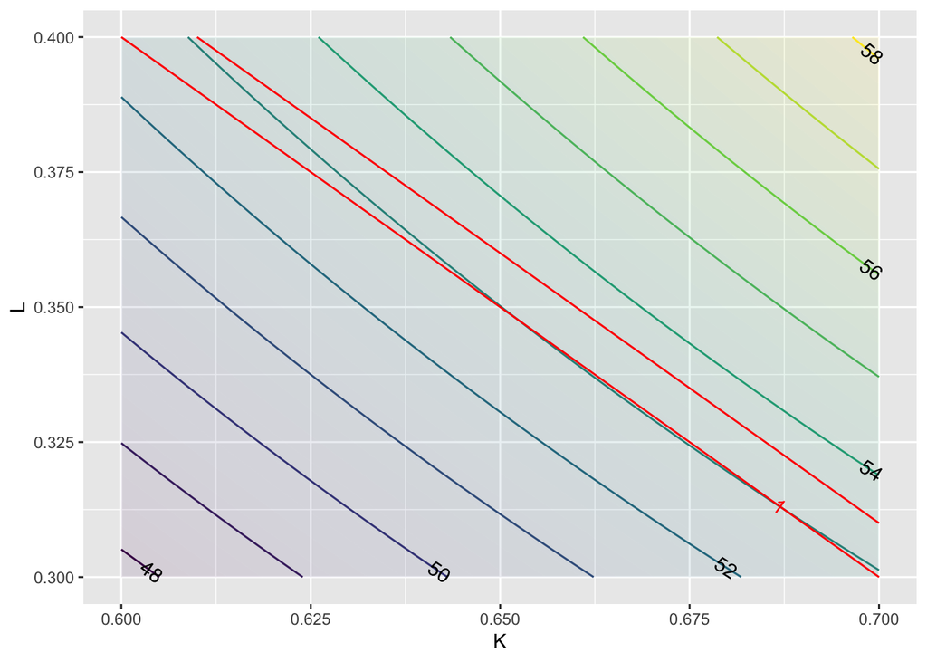

```r
P <- makeFun(b*L^a*K^(1-a) ~ K + L, a = 0.33, b=100)
g_budget <- makeFun(K + L ~ K + L)
contour_plot(P(K, L) ~ K + L, domain(K=c(.6,.7), L=c(.3,.4))) %>%
  contour_plot(g_budget(K, L) ~ K + L,
               filled=FALSE, contour_color = "red",
               contours_at = c(1, 1.01))
```

This is exactly the same graph as in the previous section but this time zoomed in around the argmax. Notice that the production function contours, which were curved in the previous section, now are practically straight lines. Yet another example of the principle in calculus that if you look closely enough around a point on a curve, the curve will seem like a straight line.

**Question tmp-1**: Maybe we were mistaken in claiming that the graph made by the code in the sandbox zooms in around the argmax. Which of these tests would allow you to determine if indeed the argmax is in the graphics frame?

1. The constraint contour is tangent to a production function contour. (+) []
2. The constraint contour crosses a production function contour. [If so, then the path of the constraint function is heading either uphill or downhill, not level.]
3. The constraint contour appears in the graphics frame. [But this doesn’t rule out the frame being somewhere other than around the argmax.]
4. The production 53 contour appears in the graphics frame. [But there are many places away from the argmax where the 53 contour appears.]

Here’s a process for determining if increasing the budget is worthwhile. It draws on information about the production function and the value of an additional widget.

1. Add a new constraint contour at a somewhat bigger budget, say $1.01M. You can do this by changing the argument `contours_at = 1` to be `contours_at = c(1, 1.01)`.
2. Calculate the production output at the new budget level.
3. Find out how much the production **output** increased from the original budget level to the new $1.01M budget level.
4. Divide the increase in the budget by the change in production (3). This is the **shadow price**/**Lagrange multiplier**. It has units of dollars/widget.

**Question tmp-2**: What’s the optimal production level when the budget is $1.01M?

1. 53.1 []
2. 53.5 (+) []
3. 54 []
4. 55.5 []

**Question tmp-3**: What’s the shadow price of producing another widget

1. $1000 per widget []
2. $5000 per widget []
3. $15,000 per widget []
4. $20,000 per widget (+) []

**Question tmp-4**: Is it worthwhile to increase the production budget?

1. Yes [So you’re willing to spend $20,000 to produce something that sells for $10,000?]
2. No (+) [Right. Who would spend $20,000 to produce something that sells for $10,000?]
3. Not enough information is available [Really? You know the cost and the benefit. That’s enough to make a decision.]